# Retail in R - Survey Data.Rmd

JRyback

November 28, 2022

# Customer Preferences

Blackwell’s sales team had engaged a marketing research firm to conduct a survey of existing customers, in part to find which of two brands, Acer or Sony, they preferred. The overall goal was to determine whether the company should enter a deeper relationship with one of the two companies, if at all. The completed survey data could then be used in further analyses of sales, brand, or product information.

Unfortunately, the data for approximately one-third of the survey results was corrupted and the brand preference was not properly captured. They came to me hoping to use machine learning to recapture the results of the corrupted part of the survey by using the uncorrupted data.

```r
library(caret)
```

```r
library(ggplot2)
library(gbm)
library(writexl)
```

The packages I will be using in this project are caret and ggplot2. Ggplot2 for the excellent visualization. Caret will help us generate our predictive models. GBM will help me examine the Gradient Boosting Machine model that we will use. The sales team requested that we return an excel file to them, so we will use writexl for the output.

## The Survey Data

The data came in two separate sets, one of the corrupted data, one of uncorrupted data.

### Uncorrupted Survey Data

```r
complete <- read.csv('SurveyData/CompleteResponses.csv')
#subbing in brand names to change data type
complete$brand <- sub('0', 'Acer', complete$brand)
complete$brand <- sub('1', 'Sony', complete$brand)
#checkiing for duplicate and null values
complete <- unique(complete)
complete <- na.omit(complete)
summary(complete)
```

```
##      salary            age            elevel           car
##  Min.   : 20000   Min.   :20.00   Min.   :0.000   Min.   : 1.00
##  1st Qu.: 52082   1st Qu.:35.00   1st Qu.:1.000   1st Qu.: 6.00
##  Median : 84950   Median :50.00   Median :2.000   Median :11.00
##  Mean   : 84871   Mean   :49.78   Mean   :1.983   Mean   :10.52
##  3rd Qu.:117162   3rd Qu.:65.00   3rd Qu.:3.000   3rd Qu.:15.75
##  Max.   :150000   Max.   :80.00   Max.   :4.000   Max.   :20.00
##     zipcode          credit          brand
##  Min.   :0.000   Min.   :     0   Length:9898
##  1st Qu.:2.000   1st Qu.:120807   Class :character
##  Median :4.000   Median :250607   Mode  :character
##  Mean   :4.041   Mean   :249176
##  3rd Qu.:6.000   3rd Qu.:374640
##  Max.   :8.000   Max.   :500000
```

### Corrupted Survey Data

```r
incomplete <- read.csv('SurveyData/SurveyIncomplete.csv')
#Get rid of incorrect brand preference data, check for duplicates/null values
incomplete <- subset(incomplete, select=-c(brand))
incomplete <- unique(incomplete)
incomplete <- na.omit(incomplete)
summary(incomplete)
```

```
##      salary            age            elevel           car
##  Min.   : 20000   Min.   :20.00   Min.   :0.000   Min.   : 1.0
##  1st Qu.: 52590   1st Qu.:35.00   1st Qu.:1.000   1st Qu.: 6.0
##  Median : 86221   Median :50.00   Median :2.000   Median :11.0
##  Mean   : 85794   Mean   :49.94   Mean   :2.009   Mean   :10.6
##  3rd Qu.:118535   3rd Qu.:65.00   3rd Qu.:3.000   3rd Qu.:16.0
##  Max.   :150000   Max.   :80.00   Max.   :4.000   Max.   :20.0
##     zipcode          credit
##  Min.   :0.000   Min.   :     0
##  1st Qu.:2.000   1st Qu.:122311
##  Median :4.000   Median :250974
##  Mean   :4.038   Mean   :249546
##  3rd Qu.:6.000   3rd Qu.:375653
##  Max.   :8.000   Max.   :500000
```

## Which customers prefer which brand?

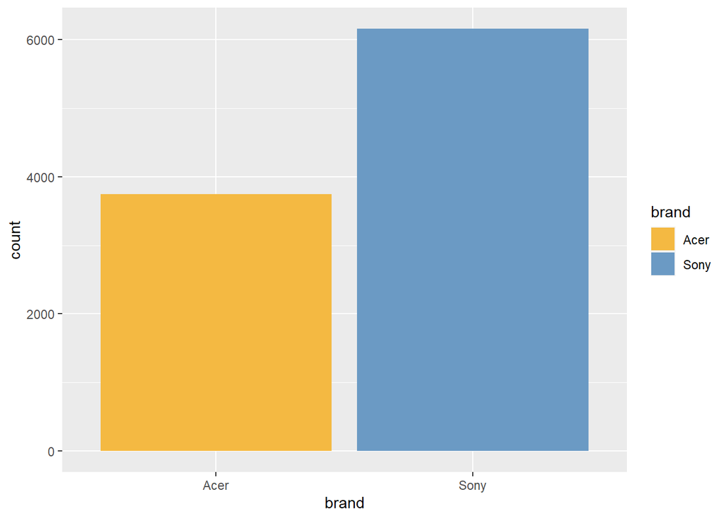

```r
ggplot(data=complete) + geom_bar(mapping=aes(brand, fill=brand)) +
  scale_fill_manual(values=c('#f4b942','#6b9ac4'))
```

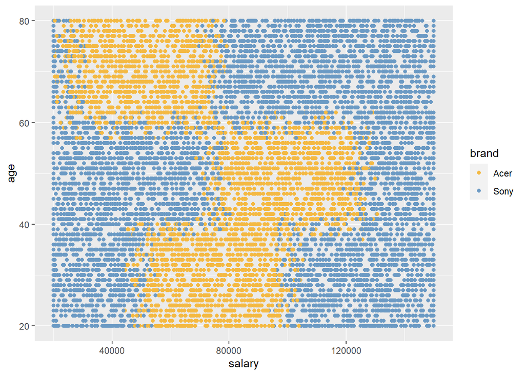

```r
ggplot(data=complete) + geom_point(mapping=aes(x=salary, y=age, color=brand))+
  scale_color_manual(values=c('#f4b942','#6b9ac4'))
```

While comparing the variables in the completed survey data, I found that the customer’s salary had the most effect on their brand preference. The second-most important variable was their age. The graph above shows that people’s preferences can be determined by age and salary, in three large groups. People under the age of 40 generally prefer to buy Acer products if they earn between $50,000 and $100,000 annually. People who prefer Acer and are between the ages of 40 and 60 have a slightly higher income on average, anywhere between $80,000 and $120,000 a year. People above 60 years old will prefer to buy Acer products if they make 20,000 to 70,000. Anyone outside of those group tend to prefer Sony over Acer. Notably, people with the highest salaries preferred Sony regardless of age.

## Can we predict a customers’ brand preference?

The brand data is binary, meaning it only has two choices for an algorithm to choose from; Sony and Acer. This bodes well for our algorithm, since binary algorithms generally do better than other types. I will be trying three different types of categorical models; Random Forest, C5.0, and Gradient Boosting Machine.

The first step is to separate the data into training and test sets. I made two sets, with the training having 75% of the uncorrupted survey data. I will test the models with a 10-fold cross-validation.

```r
set.seed(123)
inTraining <- createDataPartition(complete$brand, p=.75, list=FALSE)
train <- complete[inTraining,]
test <- complete[-inTraining,]
fitCon <- trainControl(method='repeatedcv', number=10, repeats=1)
```

### Random Forest

The first model we will try is the Random Forest Classifier.

```r
set.seed(123)
SurveyRF <- train(brand~., data=train, method='rf', trControl=fitCon, tuneLength=5)
SurveyRF
```

```
## Random Forest
##
## 7424 samples
##    6 predictor
##    2 classes: 'Acer', 'Sony'
##
## No pre-processing
## Resampling: Cross-Validated (10 fold, repeated 1 times)
## Summary of sample sizes: 6681, 6681, 6681, 6682, 6681, 6683, ...
## Resampling results across tuning parameters:
##
##   mtry  Accuracy   Kappa
##   2     0.9176981  0.8252764
##   3     0.9176985  0.8252930
##   4     0.9171598  0.8240410
##   5     0.9155429  0.8203682
##   6     0.9132536  0.8155551
##
## Accuracy was used to select the optimal model using the largest value.
## The final value used for the model was mtry = 3.
```

The highest score for the random forest’s accuracy is 91.77%. That’s very good, but we should still try the other models! The kappa is a bit lower, at 82.52. The kappa takes the expected accuracy into account and measures the agreement between inter-raters. Two raters (or more) will apply the same criteria to determine whether or not some condition occurs. For example, the raters make a prediction on which brand each person prefers based on the dependent data from the survey (age, salary, education, etc.) and the predictive algorithm used. If they agree on most accounts, then the criteria is considered reliable. Even though the kappa is a bit lower than the accuracy, it is still a very good score and can be considered reliable.

```r
confusionMatrix(SurveyRF)
```

```
## Cross-Validated (10 fold, repeated 1 times) Confusion Matrix
##
## (entries are percentual average cell counts across resamples)
##
##           Reference
## Prediction Acer Sony
##       Acer 33.9  4.3
##       Sony  4.0 57.9
##
##  Accuracy (average) : 0.9177
```

```r
varImp(SurveyRF)
```

```
## rf variable importance
##
##         Overall
## salary  100.000
## age      59.183
## credit    8.608
## car       3.207
## zipcode   1.557
## elevel    0.000
```

The salary variable was used the most, with the age as a distant second. The other variables were barely considered at all. As we saw above, the customers’ age had a significant effect on their preference.

### C5.0

The second model we will try is the C5.0 Classifier.

```r
set.seed(123)
SurveyC50 <- train(brand~., data=train, method='C5.0', trControl=fitCon, tuneLength=5)
SurveyC50
```

```
## C5.0
##
## 7424 samples
##    6 predictor
##    2 classes: 'Acer', 'Sony'
##
## No pre-processing
## Resampling: Cross-Validated (10 fold, repeated 1 times)
## Summary of sample sizes: 6681, 6681, 6681, 6682, 6681, 6683, ...
## Resampling results across tuning parameters:
##
##   model  winnow  trials  Accuracy   Kappa
##   rules  FALSE    1      0.8715035  0.7374790
##   rules  FALSE   10      0.9145968  0.8172643
##   rules  FALSE   20      0.9136557  0.8162084
##   rules  FALSE   30      0.9143285  0.8178341
##   rules  FALSE   40      0.9143285  0.8178341
##   rules   TRUE    1      0.8739270  0.7423625
##   rules   TRUE   10      0.9178316  0.8246847
##   rules   TRUE   20      0.9183689  0.8265408
##   rules   TRUE   30      0.9175606  0.8250153
##   rules   TRUE   40      0.9175606  0.8250153
##   tree   FALSE    1      0.8688088  0.7251092
##   tree   FALSE   10      0.9154085  0.8203838
##   tree   FALSE   20      0.9166194  0.8231234
##   tree   FALSE   30      0.9166198  0.8230728
##   tree   FALSE   40      0.9166198  0.8230728
##   tree    TRUE    1      0.8721757  0.7320037
##   tree    TRUE   10      0.9160781  0.8219108
##   tree    TRUE   20      0.9160772  0.8221864
##   tree    TRUE   30      0.9158081  0.8216353
##   tree    TRUE   40      0.9158081  0.8216353
##
## Accuracy was used to select the optimal model using the largest value.
## The final values used for the model were trials = 20, model = rules and
##  winnow = TRUE.
```

This one did about as well as the Random Forest model, but slightly better! The accuracy was 91.83%, while the kappa was 82.65. They’re very close!

```r
confusionMatrix(SurveyC50)
```

```
## Cross-Validated (10 fold, repeated 1 times) Confusion Matrix
##
## (entries are percentual average cell counts across resamples)
##
##           Reference
## Prediction Acer Sony
##       Acer 33.8  4.1
##       Sony  4.0 58.1
##
##  Accuracy (average) : 0.9184
```

```r
varImp(SurveyC50)
```

```
## C5.0 variable importance
##
##         Overall
## salary   100.00
## age      100.00
## credit    84.05
## car       63.08
## zipcode    0.00
## elevel     0.00
```

The C5.0 model placed the age and salary variables at equal importance. While these were the two variables that were observed to have the most effect, I wonder if putting them on an equal footing is the best solution. The credit and car variables were also factored into the algorithm. Notably, the education level and zip code had no effect.

### Gradient Boosting Machine

The third and final model we will test is the Gradient Boosting Machine model.

```r
set.seed(123)
SurveyGBM <- train(brand~., data=train, method='gbm', verbose=FALSE, trControl=fitCon, tuneLength=5)
SurveyGBM
```

```
## Stochastic Gradient Boosting
##
## 7424 samples
##    6 predictor
##    2 classes: 'Acer', 'Sony'
##
## No pre-processing
## Resampling: Cross-Validated (10 fold, repeated 1 times)
## Summary of sample sizes: 6681, 6681, 6681, 6682, 6681, 6683, ...
## Resampling results across tuning parameters:
##
##   interaction.depth  n.trees  Accuracy   Kappa
##   1                   50      0.7272367  0.4242049
##   1                  100      0.7279105  0.4245751
##   1                  150      0.7288545  0.4254531
##   1                  200      0.7271028  0.4211278
##   1                  250      0.7276414  0.4216047
##   2                   50      0.8228618  0.6278531
##   2                  100      0.8846968  0.7588787
##   2                  150      0.9063819  0.8023207
##   2                  200      0.9158113  0.8216188
##   2                  250      0.9171563  0.8244805
##   3                   50      0.8794459  0.7508510
##   3                  100      0.9062499  0.8032499
##   3                  150      0.9175639  0.8259483
##   3                  200      0.9198525  0.8303712
##   3                  250      0.9214684  0.8338808
##   4                   50      0.8911657  0.7734609
##   4                  100      0.9189094  0.8288951
##   4                  150      0.9199860  0.8309545
##   4                  200      0.9209292  0.8327892
##   4                  250      0.9202562  0.8311880
##   5                   50      0.9199874  0.8307170
##   5                  100      0.9226799  0.8361310
##   5                  150      0.9211973  0.8329874
##   5                  200      0.9201218  0.8305823
##   5                  250      0.9202564  0.8307951
##
## Tuning parameter 'shrinkage' was held constant at a value of 0.1
##
## Tuning parameter 'n.minobsinnode' was held constant at a value of 10
## Accuracy was used to select the optimal model using the largest value.
## The final values used for the model were n.trees = 100, interaction.depth =
##  5, shrinkage = 0.1 and n.minobsinnode = 10.
```

This model performed very well as well. It did better than the other models but only slightly. The best accuracy score was 92.27%, with its kappa as 83.61.

```r
confusionMatrix(SurveyGBM)
```

```
## Cross-Validated (10 fold, repeated 1 times) Confusion Matrix
##
## (entries are percentual average cell counts across resamples)
##
##           Reference
## Prediction Acer Sony
##       Acer 34.3  4.2
##       Sony  3.5 58.0
##
##  Accuracy (average) : 0.9227
```

The cross-validation shows why it performed better than the other models. The correct predictions and the incorrect Acer predictions are about the same, but a bit higher for the correct predictions, and lower for the incorrect ones. The real change is when the algorithm incorrectly predicted Sony. While both the other models predicted Sony incorrectly 4% of the time, the Gradient Boosting Machine predicted it 3.5%. While the difference is very small, when the algorithms’ accuracy are so close every bit counts.

```r
varImp(SurveyGBM)
```

```
## gbm variable importance
##
##           Overall
## salary  100.00000
## age      93.50622
## credit    1.20715
## zipcode   0.16600
## car       0.04148
## elevel    0.00000
```

As with the Random Forest Model, the salary was the most important variable, followed by the age. The importance of the age variable seems to have hit a happy medium at 93.5% - it may be the cause of the lower percent of incorrect Sony guesses. The other variables were barely considered, with the education not factoring in at all.

## Predictions

Now that we’ve run and evaluated our models, it’s time to apply them to the corrupted data!

### Gradient Boosting Machine

```r
TestGBM <- predict(SurveyGBM, newdata=incomplete, interval='prediction')
incomplete$brand <- TestGBM
summary(incomplete)
```

```
##      salary            age            elevel           car
##  Min.   : 20000   Min.   :20.00   Min.   :0.000   Min.   : 1.0
##  1st Qu.: 52590   1st Qu.:35.00   1st Qu.:1.000   1st Qu.: 6.0
##  Median : 86221   Median :50.00   Median :2.000   Median :11.0
##  Mean   : 85794   Mean   :49.94   Mean   :2.009   Mean   :10.6
##  3rd Qu.:118535   3rd Qu.:65.00   3rd Qu.:3.000   3rd Qu.:16.0
##  Max.   :150000   Max.   :80.00   Max.   :4.000   Max.   :20.0
##     zipcode          credit        brand
##  Min.   :0.000   Min.   :     0   Acer:1927
##  1st Qu.:2.000   1st Qu.:122311   Sony:3073
##  Median :4.000   Median :250974
##  Mean   :4.038   Mean   :249546
##  3rd Qu.:6.000   3rd Qu.:375653
##  Max.   :8.000   Max.   :500000
```

Here I am creating the predictions for the brand preference of the corrupted data using the other answers that the customers gave and the Gradient Boosting model. Then I can add it to the incomplete data as an additional column.

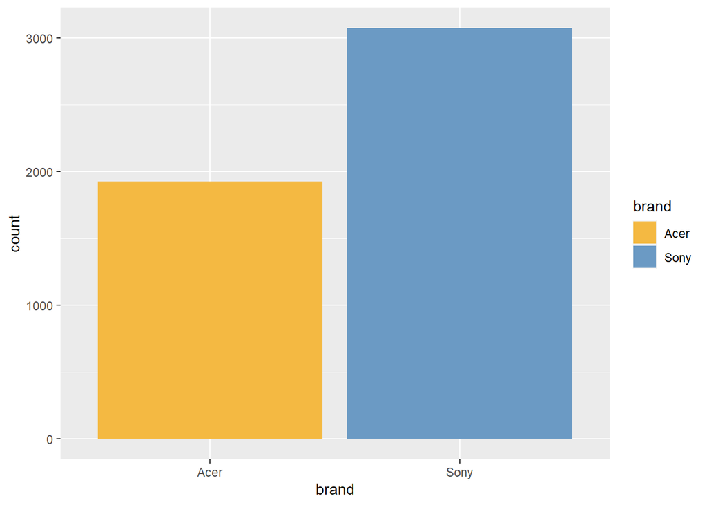

```r
ggplot(data=incomplete) + geom_bar(mapping=aes(brand, fill=brand)) +
  scale_fill_manual(values=c('#f4b942','#6b9ac4'))
```

Like the uncorrupted data, we can see that the algorithm has predicted more people preferred Sony to Acer. Next step is to combine the completed survey data with the now complete corrupted data.

```r
completedSurveyData <- rbind(complete, incomplete)
summary(completedSurveyData)
```

```
##      salary            age            elevel           car
##  Min.   : 20000   Min.   :20.00   Min.   :0.000   Min.   : 1.00
##  1st Qu.: 52287   1st Qu.:35.00   1st Qu.:1.000   1st Qu.: 6.00
##  Median : 85310   Median :50.00   Median :2.000   Median :11.00
##  Mean   : 85181   Mean   :49.83   Mean   :1.992   Mean   :10.55
##  3rd Qu.:117714   3rd Qu.:65.00   3rd Qu.:3.000   3rd Qu.:16.00
##  Max.   :150000   Max.   :80.00   Max.   :4.000   Max.   :20.00
##     zipcode         credit          brand
##  Min.   :0.00   Min.   :     0   Length:14898
##  1st Qu.:2.00   1st Qu.:121256   Class :character
##  Median :4.00   Median :250732   Mode  :character
##  Mean   :4.04   Mean   :249300
##  3rd Qu.:6.00   3rd Qu.:375199
##  Max.   :8.00   Max.   :500000
```

Now the data is all together in one nice dataset, we can take a look at everything together.

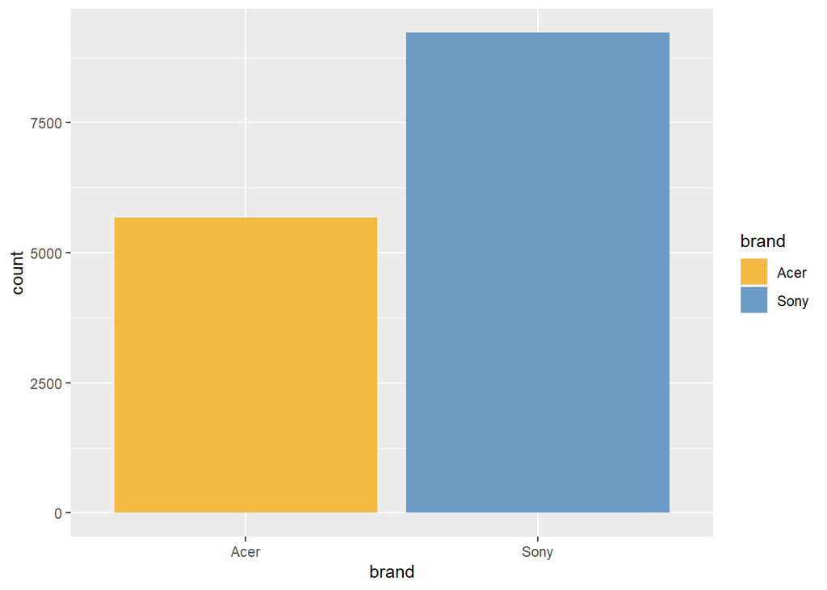

```r
ggplot(data=completedSurveyData) + geom_bar(mapping=aes(brand, fill=brand)) +
  scale_fill_manual(values=c('#f4b942','#6b9ac4'))
```

For these reasons, I would recommend that Blackwell Electronics deepen its relationship with Sony. It would encourage people who prefer Sony to come to Blackwell to purchase its products. As for the poeple who prefer Acer, the marketing team could use the age and salary information to create more targeted advertisements to draw them in.

Now all that’s left is to export the file to excel and send it on over to marketing!

```r
write_xlsx(completedSurveyData, path =tempfile(fileext='.xlsx'))
```